# **Assessment 8 - K-Means vs. DBSCAN: Choosing the Right Clustering Algorithm**

**University of Santo Tomas, College of Science**

**DSA4155: Artificial Intelligence**

Ada, John Adrian T.

Garin, Hannah Fatima T.

Mata, Bienn

Young, Eira Mae Benita P

2DSA1

### **Abstract**

##### This study explores customer segmentation using two clustering algorithms, K‑Means and DBSCAN, applied to the Credit Card Customer Segmentation dataset. Six financial features: BALANCE, PURCHASES, CASH_ADVANCE, CREDIT_LIMIT, PAYMENTS, and MINIMUM_PAYMENTS were analyzed after cleaning and scaling. K‑Means provided structured clusters based on centroid optimization, while DBSCAN revealed density‑based groupings and isolated outliers. Validation metrics and cluster profiling were used to evaluate performance. The comparison highlights the strengths and limitations of each algorithm, offering insights into which method is more practical for marketing teams seeking to understand customer behavior.

### **Objectives**

##### 1. To prepare and clean the dataset, ensuring reliable inputs for clustering analysis.

##### 2. To apply K‑Means and DBSCAN clustering, evaluate their performance using silhouette, Davies‑Bouldin, and Calinski‑Harabasz metrics, and profile customer segments.

##### 3. To compare both algorithms side‑by‑side and recommend the most suitable approach for customer segmentation in a business context.

### **Summary**

##### Results showed that DBSCAN achieved a higher Silhoutte score and a Davies-Bouldin index closer to zero (closer to zero is better for Davies-Bouldin index) while K-means had a higher Calinksi-Harabasz index. DBSCAN had better cluster cohesion while K-means (with K=3) had better cluster separation and internal density.

### **Step 1 — Data Preparation**

```python
import pandas as pd
import numpy as np

import matplotlib.pyplot as plt
from matplotlib.ticker import MaxNLocator
import seaborn as sns

from sklearn.preprocessing import StandardScaler

np.random.seed(42)
```

```python
df = pd.read_csv("CC GENERAL.csv")
features = ['BALANCE', 'PURCHASES', 'CASH_ADVANCE', 'CREDIT_LIMIT', 'PAYMENTS', 'MINIMUM_PAYMENTS']
df =  df[features]
print(f"Dataset has {df.shape[0]} rows and {df.shape[1]} columns.\n")

def look_for_missing(dataset):
    """
    required dataset that prints out the names of columns that has missing values,
    does not do anything to the dataset but look only
    """
    if dataset.isna().any().sum() > 0 or dataset.isnull().any().sum() > 0 or (dataset == '?').any().sum() > 0:
        print("Missing Values found at\n")
        dataset = dataset.isna().any()
        dataset = dataset[dataset == True].index.tolist()
        print(f"{dataset}\n")
        return dataset
    else:
        print("No missing values are found.")

df_missing = look_for_missing(dataset=df)

print(f"Found missing {df[df_missing[0]].isna().sum()} values in {df_missing[0]}")
print(f"Found missing {df[df_missing[1]].isna().sum()} values in {df_missing[1]}")

print(f"Dropping values...\n")

df = df.dropna(subset=df_missing, inplace=False)

print(f"Dropped! "
      f"New Dataset has {df.shape[0]} rows and {df.shape[1]} columns.")
```

```
Dataset has 8950 rows and 6 columns.

Missing Values found at

['CREDIT_LIMIT', 'MINIMUM_PAYMENTS']

Found missing 1 values in CREDIT_LIMIT
Found missing 313 values in MINIMUM_PAYMENTS
Dropping values...

Dropped! New Dataset has 8636 rows and 6 columns.
```

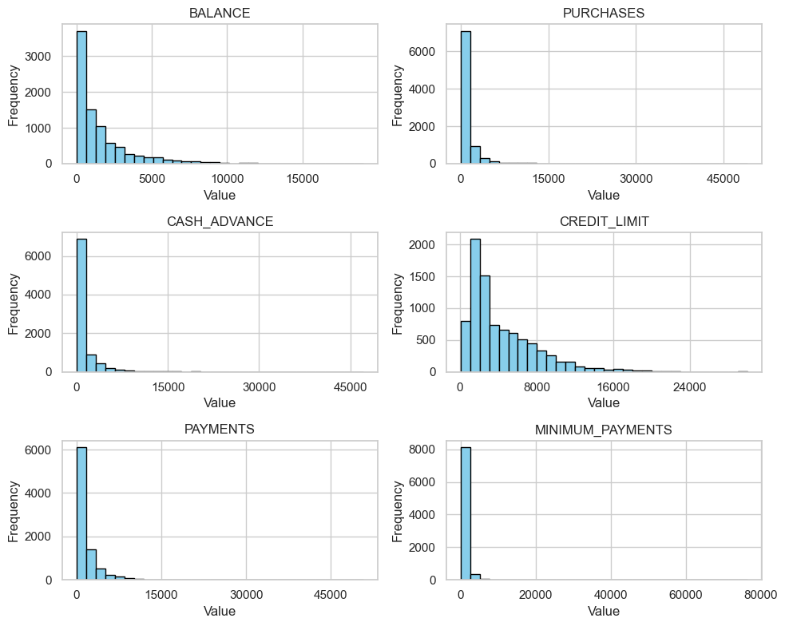

```python
fig, axs = plt.subplots(3, 2, figsize=(10, 8))

columns = df.columns.tolist()

for i, ax in enumerate(axs.flatten()):
    col = df[columns[i]]
    ax.hist(col, bins=30, color='skyblue', edgecolor='black')
    ax.set_title(columns[i])
    ax.set_xlabel('Value')
    ax.set_ylabel('Frequency')
    ax.xaxis.set_major_locator(MaxNLocator(nbins=5))

    # Zoom into the 1st–99th percentile range; uncomment to see the data zoomed in on the 99th percentile
    #ax.set_xlim(col.quantile(0.01), col.quantile(0.99))

plt.tight_layout()
plt.show()
```

From the graphs of the distribution of the features, all are right skewed where most of the data is concentrated on the left (Mean > Median > Mode, see cell below). There are potentially many outliers due to the large range of values relative to the shape of the distribution, where there could potentially be outliers on the right tail of the distribution of each feature. These outliers may be customers of a high purchasing power as seen by frequency relative to the range of values for purchases, balance and payments in particular.

```python
df.describe().transpose().round(4)

#50th percentile is the Median
```

|  | count | mean | std | min | 25% | 50% | 75% | max |
| --- | --- | --- | --- | --- | --- | --- | --- | --- |
| BALANCE | 8636.0 | 1601.2249 | 2095.5713 | 0.0000 | 148.0952 | 916.8555 | 2105.1959 | 19043.1386 |
| PURCHASES | 8636.0 | 1025.4339 | 2167.1080 | 0.0000 | 43.3675 | 375.4050 | 1145.9800 | 49039.5700 |
| CASH_ADVANCE | 8636.0 | 994.1755 | 2121.4583 | 0.0000 | 0.0000 | 0.0000 | 1132.3855 | 47137.2118 |
| CREDIT_LIMIT | 8636.0 | 4522.0910 | 3659.2404 | 50.0000 | 1600.0000 | 3000.0000 | 6500.0000 | 30000.0000 |
| PAYMENTS | 8636.0 | 1784.4781 | 2909.8101 | 0.0495 | 418.5592 | 896.6757 | 1951.1421 | 50721.4834 |
| MINIMUM_PAYMENTS | 8636.0 | 864.3049 | 2372.5664 | 0.0192 | 169.1635 | 312.4523 | 825.4965 | 76406.2075 |

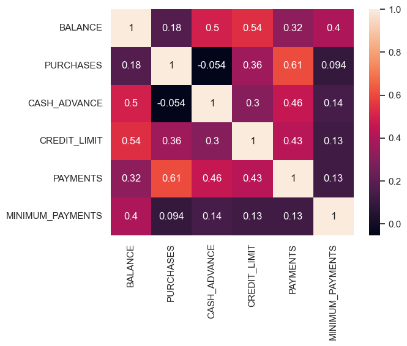

```python
sns.heatmap(df.corr(), annot=True)
```

There is a low to slight positive relationship for balance and the other features since money is important in each of these features. Credit Limit is slightly correlated with payments since higher payments lead to higher credit score leading to higher credit limit, but this is not the only singular indicator. Lastly, there is a moderate relationship between purchases and payments.

```python
scaler = StandardScaler()
X = scaler.fit_transform(df)

print("Shape of the data:", X.shape)
```

[output not shown]

### **Step 2 — K-Means Clustering**

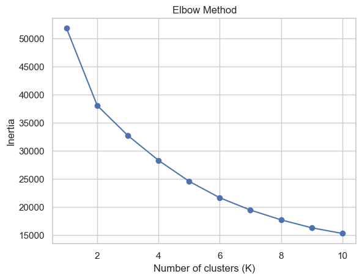

```python
from sklearn.cluster import KMeans

K_range = range(1, 11)
inertia = []

for k in K_range:
    kmeans = KMeans(n_clusters=k, random_state=42, n_init=10)
    kmeans.fit(X)
    inertia.append(kmeans.inertia_)

plt.figure()
plt.plot(K_range, inertia, marker='o')
plt.xlabel('Number of clusters (K)')
#plt.axvline(x=3, color='red', linestyle='--')
plt.ylabel('Inertia')
plt.title('Elbow Method')
plt.show()
```

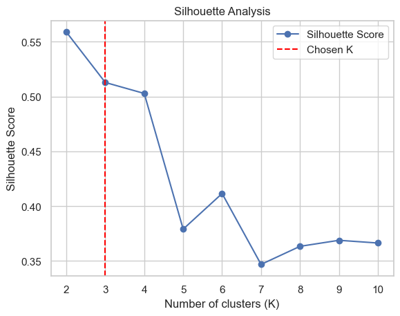

```python
from sklearn.metrics import silhouette_score

K_range = range(2, 11)
sil_scores = []

for k in K_range:
    kmeans = KMeans(n_clusters=k, random_state=42, n_init=10)
    labels = kmeans.fit_predict(X)
    sil_scores.append(silhouette_score(X, labels))

plt.figure()
plt.plot(K_range, sil_scores, marker='o')
plt.xlabel('Number of clusters (K)')
plt.ylabel('Silhouette Score')
plt.axvline(x=3, color='red', linestyle='--') #chosen K is K=3
plt.legend(['Silhouette Score', 'Chosen K'])
plt.title('Silhouette Analysis')
plt.show()
```

```python
from sklearn.cluster import KMeans
from sklearn.metrics import silhouette_score, davies_bouldin_score, calinski_harabasz_score

chosen_k = 3

kmeans = KMeans(n_clusters=chosen_k, random_state=42, n_init=10)
labels_kmeans = kmeans.fit_predict(X)
df['KMeans_Cluster'] = labels_kmeans

# Evaluation metrics
sil_avg = silhouette_score(X, labels_kmeans)
db_index = davies_bouldin_score(X, labels_kmeans)
ch_index = calinski_harabasz_score(X, labels_kmeans)

print(f"Silhouette Score: {sil_avg:.4f}")
print(f"Davies-Bouldin Index: {db_index:.4f}")
print(f"Calinski-Harabasz Index: {ch_index:.4f}")
```

```
Silhouette Score: 0.5129
Davies-Bouldin Index: 1.2825
Calinski-Harabasz Index: 2515.2800
```

The clustering model demonstrates a solid performance with a **Silhouette Score of 0.5129**, indicating that the three identified groups are well-defined and possess distinct characteristics. Furthermore, the high **Calinski-Harabasz Index of 2515.28** and a respectable **Davies-Bouldin Index of 1.2825** confirm that the clusters are both internally dense and effectively separated from one another.

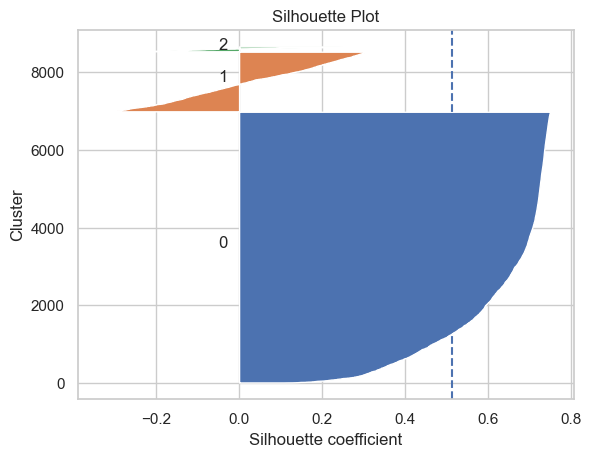

```python
from sklearn.metrics import silhouette_samples
import numpy as np
import matplotlib.pyplot as plt

sample_sil_values = silhouette_samples(X, labels_kmeans)

plt.figure()
y_lower = 10

for i in range(chosen_k):
    ith_vals = sample_sil_values[labels_kmeans == i]
    ith_vals.sort()

    size = ith_vals.shape[0]
    y_upper = y_lower + size

    plt.fill_betweenx(np.arange(y_lower, y_upper), 0, ith_vals)
    plt.text(-0.05, y_lower + size/2, str(i))

    y_lower = y_upper + 10

plt.axvline(x=sil_avg, linestyle="--")
plt.xlabel("Silhouette coefficient")
plt.ylabel("Cluster")
plt.title("Silhouette Plot")
plt.show()
```

```python
# 1. Getting the centroids from the kmeans object
centroids_scaled = kmeans.cluster_centers_

# 2. Inversing transform to get original units
centroids_original = scaler.inverse_transform(centroids_scaled)

df_centroids = pd.DataFrame(
    centroids_original,
    columns=['BALANCE', 'PURCHASES', 'CASH_ADVANCE', 'CREDIT_LIMIT', 'PAYMENTS', 'MINIMUM_PAYMENTS']
)

print("Cluster Centroids in Original Units:")
display(df_centroids)
```

```
Cluster Centroids in Original Units:
```

|  | BALANCE | PURCHASES | CASH_ADVANCE | CREDIT_LIMIT | PAYMENTS | MINIMUM_PAYMENTS |
| --- | --- | --- | --- | --- | --- | --- |
| 0 | 853.71602 | 764.117148 | 449.706936 | 3407.305062 | 1155.988360 | 480.118948 |
| 1 | 4725.85183 | 1383.896792 | 3117.906628 | 8923.931523 | 3304.168991 | 2476.719449 |
| 2 | 4792.89586 | 11182.281920 | 5193.732493 | 12460.800000 | 18111.502079 | 2424.642761 |

## Interpretation:

**Cluster 0** - Customers with below-average balances, purchases, cash advances, credit limits, payments, and minimum payments, indicating low overall credit card usage and engagement.

**Cluster 1** - Customers with high balances and credit limits, moderate cash advances and payments, but generally average purchasing behavior, suggesting active but controlled credit usage.

**Cluster 2** - Customers with very high purchases, payments, and credit limits, along with high balances and cash advances, indicating heavy and highly active credit card users.

### **Step 3 — DBSCAN Clustering**

```python
from sklearn.preprocessing import StandardScaler

scaler = StandardScaler()
X_scaled = scaler.fit_transform(df.drop(columns=['KMeans_Cluster']))
```

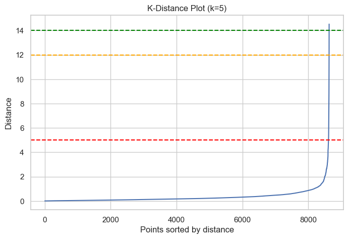

```python
from sklearn.neighbors import NearestNeighbors
import numpy as np
import matplotlib.pyplot as plt

neighbors = NearestNeighbors(n_neighbors=5)
neighbors_fit = neighbors.fit(X_scaled)
distances, indices = neighbors_fit.kneighbors(X_scaled)

distances = np.sort(distances[:, 4])


plt.figure(figsize=(8,5))
plt.plot(distances)
plt.title('K-Distance Plot (k=5)')
plt.xlabel('Points sorted by distance')
plt.ylabel('Distance')
plt.axhline(y=14, color='green', linestyle='--')
plt.axhline(y=12, color='orange', linestyle='--')
plt.axhline(y=5, color='red', linestyle='--')
plt.show()
```

#### 3.1 Test multiple eps values

```python
from sklearn.cluster import DBSCAN

eps_values = [2, 4, 6, 8, 10, 12, 14, 16]
results = []

for eps in eps_values:
    dbscan = DBSCAN(eps=eps, min_samples=5)
    labels_test = dbscan.fit_predict(X_scaled)

    n_clusters = len(set(labels_test)) - (1 if -1 in labels_test else 0)
    n_noise = list(labels_test).count(-1)
    noise_pct = n_noise / len(labels_test) * 100

    results.append([eps, n_clusters, n_noise, f"{noise_pct:.2f}%"])

df_results = pd.DataFrame(results, columns=["eps", "Clusters Found", "Noise Points", "Noise %"])
print(df_results.to_string(index=False))
```

```
 eps  Clusters Found  Noise Points Noise %
   2               3            91   1.05%
   4               1            22   0.25%
   6               1             8   0.09%
   8               1             2   0.02%
  10               1             0   0.00%
  12               1             0   0.00%
  14               1             0   0.00%
  16               1             0   0.00%
```

**Interpretation:**

- At eps = 2, DBSCAN identified three clusters and flagged 91 noise points (~1.05%). This is the only configuration that produced multiple clusters, and the small noise percentage is desirable because it shows DBSCAN successfully isolated a few outliers without discarding too many customers.
- At eps = 4, 6, and 8, DBSCAN collapsed into a single cluster, with only a handful of points marked as noise. As eps increases, DBSCAN becomes more permissive, merging all customers into one group and reducing noise, but at the cost of losing meaningful segmentation.
- At eps ≥ 10, DBSCAN produced one cluster with zero noise. At these values, the algorithm treats the dataset as one dense blob, which defeats the purpose of DBSCAN, where its strength lies in finding density-based structure and isolating outliers.

**Conclusion:** At least four eps values were tested, with additional values checked for completeness. The most informative configuration was eps = 2, min_samples = 5, because it produced multiple clusters and a small but nontrivial set of noise points. Larger values of eps failed to capture the density variations in the dataset, making DBSCAN ineffective for segmentation.

#### 3.2 Fit DBSCAN with chosen parameters

```python
chosen_eps = 2
dbscan = DBSCAN(eps=chosen_eps, min_samples=5)
labels_dbscan = dbscan.fit_predict(X_scaled)

# Filter out noise (-1)
mask = labels_dbscan != -1
X_non_noise = X_scaled[mask]
labels_non_noise = labels_dbscan[mask]

n_clusters = len(set(labels_non_noise))

if n_clusters > 1:
    sil_avg_dbscan = silhouette_score(X_non_noise, labels_non_noise)
    db_index_dbscan = davies_bouldin_score(X_non_noise, labels_non_noise)
    ch_index_dbscan = calinski_harabasz_score(X_non_noise, labels_non_noise)

    print(f"Silhouette Score: {sil_avg_dbscan:.4f}")
    print(f"Davies-Bouldin Index: {db_index_dbscan:.4f}")
    print(f"Calinski-Harabasz Index: {ch_index_dbscan:.4f}")
else:
    print(f"DBSCAN produced only {n_clusters} cluster(s). Metrics requiring ≥2 clusters cannot be computed.")
```

```
Silhouette Score: 0.7062
Davies-Bouldin Index: 0.5010
Calinski-Harabasz Index: 83.8014
```

**Interpretation:**

- The silhouette score (0.71) is high, which means the clusters are well separated and the points inside each cluster are very similar to each other.
- The Davies-Bouldin index (0.50) is low, which means the clusters are compact and don’t overlap much.
- The Calinski-Harabasz index (83.8) shows that the clusters are reasonably well defined compared to the spread of the data.

Therefore, DBSCAN with these parameters found three clear customer groups and a small set of outliers (~1%). The clusters are strong and distinct, while the noise points represent unusual customers that don’t fit neatly into any group. This makes DBSCAN effective here because it highlights both the main customer segments and the rare, irregular cases that K-Means would have forced into a cluster.

#### 3.3 Cluster profiling

```python
df['DBSCAN_Cluster'] = labels_dbscan

# Profile clusters (excluding noise)
cluster_profiles = (
    df[df['DBSCAN_Cluster'] != -1]
    .groupby('DBSCAN_Cluster')
    .mean(numeric_only=True)
)
print("Cluster Profiles (Original Units):")
print(cluster_profiles)

# Profile noise separately
noise_profile = (
    df[df['DBSCAN_Cluster'] == -1]
    .mean(numeric_only=True)
)
print("\nNoise Profile (Original Units):")
print(noise_profile)
```

```
Cluster Profiles (Original Units):
                    BALANCE    PURCHASES  CASH_ADVANCE  CREDIT_LIMIT  \
DBSCAN_Cluster
0               1543.063749   924.268687    925.130053    4418.62443
1               2661.934608    23.400000  16608.180762    9800.00000
2               6710.076504  2611.635000   8677.745811   13375.00000

                    PAYMENTS  MINIMUM_PAYMENTS  KMeans_Cluster
DBSCAN_Cluster
0                1596.679032        777.420965        0.189316
1               16535.948902        726.720842        1.800000
2               19230.355288       2561.764634        2.000000

Noise Profile (Original Units):
BALANCE              6774.022361
PURCHASES           10500.284505
CASH_ADVANCE         6275.140598
CREDIT_LIMIT        13548.351648
PAYMENTS            17823.071254
MINIMUM_PAYMENTS     8947.158963
KMeans_Cluster          1.692308
DBSCAN_Cluster         -1.000000
dtype: float64
```

**Interpretation:**

- **Cluster 0 – Low‑balance, moderate spenders** (Balance ~1.5k, Purchases ~924)

This group maintains relatively small balances and moderate purchase activity, with the lowest credit limits and manageable minimum payments. They represent typical, lower‑risk customers who use their cards steadily but conservatively.

- **Cluster 1 – Cash‑advance heavy users** (Cash Advance ~16.6k, Purchases ~23)

These customers rarely make purchases but rely heavily on cash advances, resulting in very high repayment amounts. Their behavior suggests they use credit cards primarily for liquidity rather than shopping, making them distinct from traditional spenders.

- **Cluster 2 – High‑balance, high‑spending customers** (Balance ~6.7k, Purchases ~2.6k, Min Payments ~2.6k)

This segment carries the largest balances, makes substantial purchases, and has the highest credit limits. They also have very high payments and minimum obligations, reflecting financially active customers who may be premium clients or higher‑risk borrowers depending on repayment consistency.

The noise points represent unusual customers with exceptionally high purchases and unusually large minimum payments. DBSCAN correctly isolates them as outliers, highlighting irregular spending patterns that do not fit neatly into any cluster.

### **Step 4 — Comparison and Recommendation**

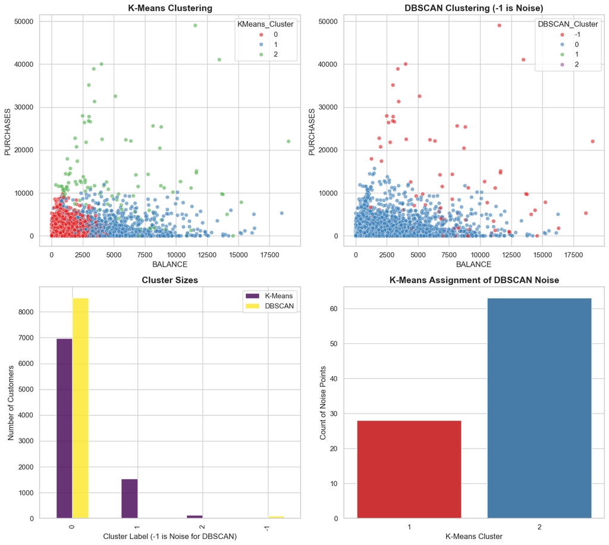

```python
metrics = []
metrics.append({'Algorithm': 'K-Means', 'Silhouette Score': sil_avg, 'Davies-Bouldin': db_index, 'Calinski-Harabasz': ch_index})
metrics.append({'Algorithm': 'DBSCAN', 'Silhouette Score': sil_avg_dbscan, 'Davies-Bouldin': db_index_dbscan, 'Calinski-Harabasz': ch_index_dbscan})
metrics_df = pd.DataFrame(metrics)

fig = plt.figure(figsize=(20, 12))

# K-Means Scatterplot
ax1 = plt.subplot(2, 3, 1)
sns.scatterplot(data=df, x='BALANCE', y='PURCHASES', hue='KMeans_Cluster', palette='Set1', alpha=0.6, ax=ax1)
ax1.set_title('K-Means Clustering', fontsize=14, fontweight='bold')

# DBSCAN Scatterplot
ax2 = plt.subplot(2, 3, 2)
sns.scatterplot(data=df, x='BALANCE', y='PURCHASES', hue='DBSCAN_Cluster', palette='Set1', alpha=0.6, ax=ax2)
ax2.set_title('DBSCAN Clustering (-1 is Noise)', fontsize=14, fontweight='bold')

# Cluster Sizes
ax4 = plt.subplot(2, 3, 4)
# Grouped bar chart for sizes
k_counts = df['KMeans_Cluster'].value_counts().rename('K-Means')
d_counts = df['DBSCAN_Cluster'].value_counts().rename('DBSCAN')
cluster_counts = pd.concat([k_counts, d_counts], axis=1).fillna(0)

cluster_counts.plot(kind='bar', ax=ax4, colormap='viridis', alpha=0.8)
ax4.set_title('Cluster Sizes', fontsize=14, fontweight='bold')
ax4.set_ylabel('Number of Customers')
ax4.set_xlabel('Cluster Label (-1 is Noise for DBSCAN)')

# DBSCAN Noise in K-means
ax5 = plt.subplot(2, 3, 5)
noise_df = df[df['DBSCAN_Cluster'] == -1]
sns.countplot(data=noise_df, x='KMeans_Cluster', palette='Set1', ax=ax5)
ax5.set_title('K-Means Assignment of DBSCAN Noise', fontsize=14, fontweight='bold')
ax5.set_ylabel('Count of Noise Points')
ax5.set_xlabel('K-Means Cluster')

plt.tight_layout()
```

```python
print(metrics_df.to_string(index=False))
```

```
Algorithm  Silhouette Score  Davies-Bouldin  Calinski-Harabasz
  K-Means          0.512905        1.282536        2515.279981
   DBSCAN          0.706173        0.501006          83.801433
```

```python
count_df = pd.DataFrame({
    'KMeans_Cluster': df['KMeans_Cluster'].value_counts(),
    'DBSCAN_Cluster': df['DBSCAN_Cluster'].value_counts()
})

print("Cluster Counts for K-Means and DBSCAN:"
      f"\n{count_df.to_string()}")
```

```
Cluster Counts for K-Means and DBSCAN:
    KMeans_Cluster  DBSCAN_Cluster
-1             NaN              91
 0          6974.0            8536
 1          1537.0               5
 2           125.0               4
```

#### **Recommendation: K-Means Clustering**

From the results, most of the noise from Density Based Clustering (DBSCAN) was assigned to Cluster 2 of K-means, the cluster that includes customers with very high purchases and credit limits. This makes sense since these customers are more likely to be outliers, as seen in the histograms of the six features all being right skewed, including Balance and Purchases. In a business context, if the outliers are customers with high purchases and credit limits, and therefore a higher purchasing power, then they are to be generalized as part of Cluster 2 or 1 instead of being classified as noise. Revenue can be simplified as $price \times quantity$, which means that the marketing department can either generate sales by selling a large quantity that appeals to the majority (customers part of Cluster 0; low balance and moderate spenders) or by selling at a higher yet still profitable price towards customers part of Cluster 2.

However, as defined previously, Cluster 2 (and most of the values marked as noise for DBSCAN) contain customers that are already high-spending customers with high payments, credit limits and payments, which allows them to spend more, which is the goal of a marketing team: to target customers that can spend and use their credit card. It is worth noting that there were still around thirty customers that were assigned to Cluster 1 of K-means from the DBSCAN noise; these customers have high balances and credit limits but with moderate cash advances. These customers cannot be discarded as noise, as done by DBSCAN, because they can still be generalized as customers with high purchasing power. Assigning the outliers to clusters 1 and 2, as done by K-means, allows a marketing team to focus on high spending customers, even customers with the potential to spend due to a high purchasing power, thus giving a marketing department more flexibility in their strategies. Therefore, K-means clustering lands a recommendation due to the given context of a business and marketing.